# How Does a Bike-Share Navigate Speedy Success?

By: Toh Jing Qiang

1 Dec 2021

[figure not shown]

# Scenario

I am a junior data analyst working in the marketing analyst team at Cyclistic, a bike-share company in Chicago. The director of marketing believes the company’s future success depends on maximizing the number of annual memberships. Therefore, my team wants to understand how casual riders and annual members use Cyclistic bikes differently. From these insights, my team will design a new marketing strategy to convert casual riders into annual members. But first, Cyclistic executives must approve my recommendations, so they must be backed up with compelling data insights and professional data visualizations.

# Ask:

### Business Task

- How do annual members and casual riders use Cyclistic bikes differently?
- Analyse how annual members and causal riders use Cyclistic bikes differently and provide data-driven recommendations for a new marketing strategy to convert causal riders to members

### Key Stakeholders

- **Lily Monero**: Director of Marketing and my manager
- **Cyclistic Marketing analytics team**: Team of data analysts
- **Cyclists executive team**: Stakeholder approving recommendations

# Prepare

### Libraries used

```r
library(tidyverse)
library(lubridate)
library(ggplot2)
```

### Step 1: Collect Data

Upload Divvy Datasets:

```r
q2_2019 <- read.csv("Dataset/Raw/Divvy_Trips_2019_Q2.csv")
q3_2019 <- read.csv("Dataset/Raw/Divvy_Trips_2019_Q3.csv")
q4_2019 <- read.csv("Dataset/Raw/Divvy_Trips_2019_Q4.csv")
q1_2020 <- read.csv("Dataset/Raw/Divvy_Trips_2020_Q1.csv")
```

### Step 2: Wrangle data and combine into a single file

Compare column names of each data set:

```r
colnames(q1_2020)
```

```
##  [1] "ride_id"            "rideable_type"      "started_at"
##  [4] "ended_at"           "start_station_name" "start_station_id"
##  [7] "end_station_name"   "end_station_id"     "start_lat"
## [10] "start_lng"          "end_lat"            "end_lng"
## [13] "member_casual"
```

```r
colnames(q4_2019)
```

```
##  [1] "trip_id"           "start_time"        "end_time"
##  [4] "bikeid"            "tripduration"      "from_station_id"
##  [7] "from_station_name" "to_station_id"     "to_station_name"
## [10] "usertype"          "gender"            "birthyear"
```

```r
colnames(q3_2019)
```

```
##  [1] "trip_id"           "start_time"        "end_time"
##  [4] "bikeid"            "tripduration"      "from_station_id"
##  [7] "from_station_name" "to_station_id"     "to_station_name"
## [10] "usertype"          "gender"            "birthyear"
```

```r
colnames(q2_2019)
```

```
##  [1] "X01...Rental.Details.Rental.ID"
##  [2] "X01...Rental.Details.Local.Start.Time"
##  [3] "X01...Rental.Details.Local.End.Time"
##  [4] "X01...Rental.Details.Bike.ID"
##  [5] "X01...Rental.Details.Duration.In.Seconds.Uncapped"
##  [6] "X03...Rental.Start.Station.ID"
##  [7] "X03...Rental.Start.Station.Name"
##  [8] "X02...Rental.End.Station.ID"
##  [9] "X02...Rental.End.Station.Name"
## [10] "User.Type"
## [11] "Member.Gender"
## [12] "X05...Member.Details.Member.Birthday.Year"
```

There is inconsistency in the column names across each data set.

Rename column names to make it consistent with q1_2020:

```r
q2_2019 <- rename(q2_2019
                  ,ride_id = "X01...Rental.Details.Rental.ID"
                  ,rideable_type = "X01...Rental.Details.Bike.ID"
                  ,started_at = "X01...Rental.Details.Local.Start.Time"
                  ,ended_at = "X01...Rental.Details.Local.End.Time"
                  ,start_station_name = "X03...Rental.Start.Station.Name"
                  ,start_station_id = "X03...Rental.Start.Station.ID"
                  ,end_station_name = "X02...Rental.End.Station.Name"
                  ,end_station_id = "X02...Rental.End.Station.ID"
                  ,member_casual = "User.Type"
                  ,tripduration = "X01...Rental.Details.Duration.In.Seconds.Uncapped"
                  ,gender = "Member.Gender"
                  ,birthyear = "X05...Member.Details.Member.Birthday.Year")
q3_2019 <- rename(q3_2019
                  ,ride_id = trip_id
                  ,rideable_type = bikeid
                  ,started_at = start_time
                  ,ended_at = end_time
                  ,start_station_name = from_station_name
                  ,start_station_id = from_station_id
                  ,end_station_name = to_station_name
                  ,end_station_id = to_station_id
                  ,member_casual = usertype)
q4_2019 <- rename(q4_2019
                  ,ride_id = trip_id
                  ,rideable_type = bikeid
                  ,started_at = start_time
                  ,ended_at = end_time
                  ,start_station_name = from_station_name
                  ,start_station_id = from_station_id
                  ,end_station_name = to_station_name
                  ,end_station_id = to_station_id
                  ,member_casual = usertype)
```

Compare column names of each data frame again:

```r
colnames(q1_2020)
```

```
##  [1] "ride_id"            "rideable_type"      "started_at"
##  [4] "ended_at"           "start_station_name" "start_station_id"
##  [7] "end_station_name"   "end_station_id"     "start_lat"
## [10] "start_lng"          "end_lat"            "end_lng"
## [13] "member_casual"
```

```r
colnames(q4_2019)
```

```
##  [1] "ride_id"            "started_at"         "ended_at"
##  [4] "rideable_type"      "tripduration"       "start_station_id"
##  [7] "start_station_name" "end_station_id"     "end_station_name"
## [10] "member_casual"      "gender"             "birthyear"
```

```r
colnames(q3_2019)
```

```
##  [1] "ride_id"            "started_at"         "ended_at"
##  [4] "rideable_type"      "tripduration"       "start_station_id"
##  [7] "start_station_name" "end_station_id"     "end_station_name"
## [10] "member_casual"      "gender"             "birthyear"
```

```r
colnames(q2_2019)
```

```
##  [1] "ride_id"            "started_at"         "ended_at"
##  [4] "rideable_type"      "tripduration"       "start_station_id"
##  [7] "start_station_name" "end_station_id"     "end_station_name"
## [10] "member_casual"      "gender"             "birthyear"
```

Column names of are consistent now.

Inspect the data frames and look for inconsistency:

```r
str(q1_2020)
```

```
## 'data.frame':    426887 obs. of  13 variables:
##  $ ride_id           : chr  "EACB19130B0CDA4A" "8FED874C809DC021" "789F3C21E472CA96" "C9A388DAC6ABF313" ...
##  $ rideable_type     : chr  "docked_bike" "docked_bike" "docked_bike" "docked_bike" ...
##  $ started_at        : chr  "2020-01-21 20:06:59" "2020-01-30 14:22:39" "2020-01-09 19:29:26" "2020-01-06 16:17:07" ...
##  $ ended_at          : chr  "2020-01-21 20:14:30" "2020-01-30 14:26:22" "2020-01-09 19:32:17" "2020-01-06 16:25:56" ...
##  $ start_station_name: chr  "Western Ave & Leland Ave" "Clark St & Montrose Ave" "Broadway & Belmont Ave" "Clark St & Randolph St" ...
##  $ start_station_id  : int  239 234 296 51 66 212 96 96 212 38 ...
##  $ end_station_name  : chr  "Clark St & Leland Ave" "Southport Ave & Irving Park Rd" "Wilton Ave & Belmont Ave" "Fairbanks Ct & Grand Ave" ...
##  $ end_station_id    : int  326 318 117 24 212 96 212 212 96 100 ...
##  $ start_lat         : num  42 42 41.9 41.9 41.9 ...
##  $ start_lng         : num  -87.7 -87.7 -87.6 -87.6 -87.6 ...
##  $ end_lat           : num  42 42 41.9 41.9 41.9 ...
##  $ end_lng           : num  -87.7 -87.7 -87.7 -87.6 -87.6 ...
##  $ member_casual     : chr  "member" "member" "member" "member" ...
```

```r
str(q4_2019)
```

```
## 'data.frame':    704054 obs. of  12 variables:
##  $ ride_id           : int  25223640 25223641 25223642 25223643 25223644 25223645 25223646 25223647 25223648 25223649 ...
##  $ started_at        : chr  "2019-10-01 00:01:39" "2019-10-01 00:02:16" "2019-10-01 00:04:32" "2019-10-01 00:04:32" ...
##  $ ended_at          : chr  "2019-10-01 00:17:20" "2019-10-01 00:06:34" "2019-10-01 00:18:43" "2019-10-01 00:43:43" ...
##  $ rideable_type     : int  2215 6328 3003 3275 5294 1891 1061 1274 6011 2957 ...
##  $ tripduration      : chr  "940.0" "258.0" "850.0" "2,350.0" ...
##  $ start_station_id  : int  20 19 84 313 210 156 84 156 156 336 ...
##  $ start_station_name: chr  "Sheffield Ave & Kingsbury St" "Throop (Loomis) St & Taylor St" "Milwaukee Ave & Grand Ave" "Lakeview Ave & Fullerton Pkwy" ...
##  $ end_station_id    : int  309 241 199 290 382 226 142 463 463 336 ...
##  $ end_station_name  : chr  "Leavitt St & Armitage Ave" "Morgan St & Polk St" "Wabash Ave & Grand Ave" "Kedzie Ave & Palmer Ct" ...
##  $ member_casual     : chr  "Subscriber" "Subscriber" "Subscriber" "Subscriber" ...
##  $ gender            : chr  "Male" "Male" "Female" "Male" ...
##  $ birthyear         : int  1987 1998 1991 1990 1987 1994 1991 1995 1993 NA ...
```

```r
str(q3_2019)
```

```
## 'data.frame':    1640718 obs. of  12 variables:
##  $ ride_id           : int  23479388 23479389 23479390 23479391 23479392 23479393 23479394 23479395 23479396 23479397 ...
##  $ started_at        : chr  "2019-07-01 00:00:27" "2019-07-01 00:01:16" "2019-07-01 00:01:48" "2019-07-01 00:02:07" ...
##  $ ended_at          : chr  "2019-07-01 00:20:41" "2019-07-01 00:18:44" "2019-07-01 00:27:42" "2019-07-01 00:27:10" ...
##  $ rideable_type     : int  3591 5353 6180 5540 6014 4941 3770 5442 2957 6091 ...
##  $ tripduration      : chr  "1,214.0" "1,048.0" "1,554.0" "1,503.0" ...
##  $ start_station_id  : int  117 381 313 313 168 300 168 313 43 43 ...
##  $ start_station_name: chr  "Wilton Ave & Belmont Ave" "Western Ave & Monroe St" "Lakeview Ave & Fullerton Pkwy" "Lakeview Ave & Fullerton Pkwy" ...
##  $ end_station_id    : int  497 203 144 144 62 232 62 144 195 195 ...
##  $ end_station_name  : chr  "Kimball Ave & Belmont Ave" "Western Ave & 21st St" "Larrabee St & Webster Ave" "Larrabee St & Webster Ave" ...
##  $ member_casual     : chr  "Subscriber" "Customer" "Customer" "Customer" ...
##  $ gender            : chr  "Male" "" "" "" ...
##  $ birthyear         : int  1992 NA NA NA NA 1990 NA NA NA NA ...
```

```r
str(q2_2019)
```

```
## 'data.frame':    1108163 obs. of  12 variables:
##  $ ride_id           : int  22178529 22178530 22178531 22178532 22178533 22178534 22178535 22178536 22178537 22178538 ...
##  $ started_at        : chr  "2019-04-01 00:02:22" "2019-04-01 00:03:02" "2019-04-01 00:11:07" "2019-04-01 00:13:01" ...
##  $ ended_at          : chr  "2019-04-01 00:09:48" "2019-04-01 00:20:30" "2019-04-01 00:15:19" "2019-04-01 00:18:58" ...
##  $ rideable_type     : int  6251 6226 5649 4151 3270 3123 6418 4513 3280 5534 ...
##  $ tripduration      : chr  "446.0" "1,048.0" "252.0" "357.0" ...
##  $ start_station_id  : int  81 317 283 26 202 420 503 260 211 211 ...
##  $ start_station_name: chr  "Daley Center Plaza" "Wood St & Taylor St" "LaSalle St & Jackson Blvd" "McClurg Ct & Illinois St" ...
##  $ end_station_id    : int  56 59 174 133 129 426 500 499 211 211 ...
##  $ end_station_name  : chr  "Desplaines St & Kinzie St" "Wabash Ave & Roosevelt Rd" "Canal St & Madison St" "Kingsbury St & Kinzie St" ...
##  $ member_casual     : chr  "Subscriber" "Subscriber" "Subscriber" "Subscriber" ...
##  $ gender            : chr  "Male" "Female" "Male" "Male" ...
##  $ birthyear         : int  1975 1984 1990 1993 1992 1999 1969 1991 NA NA ...
```

Convert ‘ride_id’ and ‘rideable_type’ to character so that they are consistent across data frames:

```r
q4_2019 <-  mutate(q4_2019, ride_id = as.character(ride_id)
                   ,rideable_type = as.character(rideable_type))
q3_2019 <-  mutate(q3_2019, ride_id = as.character(ride_id)
                   ,rideable_type = as.character(rideable_type))
q2_2019 <-  mutate(q2_2019, ride_id = as.character(ride_id)
                   ,rideable_type = as.character(rideable_type))
```

### Combine individual quarter’s data frames into one data frame

```r
divvy_trips <- bind_rows(q2_2019, q3_2019, q4_2019, q1_2020)
head(divvy_trips)
```

```
##    ride_id          started_at            ended_at rideable_type tripduration
## 1 22178529 2019-04-01 00:02:22 2019-04-01 00:09:48          6251        446.0
## 2 22178530 2019-04-01 00:03:02 2019-04-01 00:20:30          6226      1,048.0
## 3 22178531 2019-04-01 00:11:07 2019-04-01 00:15:19          5649        252.0
## 4 22178532 2019-04-01 00:13:01 2019-04-01 00:18:58          4151        357.0
## 5 22178533 2019-04-01 00:19:26 2019-04-01 00:36:13          3270      1,007.0
## 6 22178534 2019-04-01 00:19:39 2019-04-01 00:23:56          3123        257.0
##   start_station_id        start_station_name end_station_id
## 1               81        Daley Center Plaza             56
## 2              317       Wood St & Taylor St             59
## 3              283 LaSalle St & Jackson Blvd            174
## 4               26  McClurg Ct & Illinois St            133
## 5              202      Halsted St & 18th St            129
## 6              420       Ellis Ave & 55th St            426
##            end_station_name member_casual gender birthyear start_lat start_lng
## 1 Desplaines St & Kinzie St    Subscriber   Male      1975        NA        NA
## 2 Wabash Ave & Roosevelt Rd    Subscriber Female      1984        NA        NA
## 3     Canal St & Madison St    Subscriber   Male      1990        NA        NA
## 4  Kingsbury St & Kinzie St    Subscriber   Male      1993        NA        NA
## 5 Blue Island Ave & 18th St    Subscriber   Male      1992        NA        NA
## 6       Ellis Ave & 60th St    Subscriber   Male      1999        NA        NA
##   end_lat end_lng
## 1      NA      NA
## 2      NA      NA
## 3      NA      NA
## 4      NA      NA
## 5      NA      NA
## 6      NA      NA
```

Remove ‘birthyear’, ‘gender’ and ‘tripduration’ as this data was not included in q1 2020. Remove lat and long as it was only included in q1 2020:

```r
divvy_trips <- divvy_trips %>%
  select(-c(birthyear, gender, tripduration
            , start_lat, start_lng, end_lat, end_lng))
colnames(divvy_trips)
```

```
## [1] "ride_id"            "started_at"         "ended_at"
## [4] "rideable_type"      "start_station_id"   "start_station_name"
## [7] "end_station_id"     "end_station_name"   "member_casual"
```

# Process

### Step 3: Clean up and Add Data to prepare for analysis

Inspect the new table that has been created:

```r
# column names
colnames(divvy_trips)
```

```
## [1] "ride_id"            "started_at"         "ended_at"
## [4] "rideable_type"      "start_station_id"   "start_station_name"
## [7] "end_station_id"     "end_station_name"   "member_casual"
```

```r
# number of rows
nrow(divvy_trips)
```

```
## [1] 3879822
```

```r
# dimension of data frame
dim(divvy_trips)
```

```
## [1] 3879822       9
```

```r
# first/last 6 rows of data fram
head(divvy_trips)
```

```
##    ride_id          started_at            ended_at rideable_type
## 1 22178529 2019-04-01 00:02:22 2019-04-01 00:09:48          6251
## 2 22178530 2019-04-01 00:03:02 2019-04-01 00:20:30          6226
## 3 22178531 2019-04-01 00:11:07 2019-04-01 00:15:19          5649
## 4 22178532 2019-04-01 00:13:01 2019-04-01 00:18:58          4151
## 5 22178533 2019-04-01 00:19:26 2019-04-01 00:36:13          3270
## 6 22178534 2019-04-01 00:19:39 2019-04-01 00:23:56          3123
##   start_station_id        start_station_name end_station_id
## 1               81        Daley Center Plaza             56
## 2              317       Wood St & Taylor St             59
## 3              283 LaSalle St & Jackson Blvd            174
## 4               26  McClurg Ct & Illinois St            133
## 5              202      Halsted St & 18th St            129
## 6              420       Ellis Ave & 55th St            426
##            end_station_name member_casual
## 1 Desplaines St & Kinzie St    Subscriber
## 2 Wabash Ave & Roosevelt Rd    Subscriber
## 3     Canal St & Madison St    Subscriber
## 4  Kingsbury St & Kinzie St    Subscriber
## 5 Blue Island Ave & 18th St    Subscriber
## 6       Ellis Ave & 60th St    Subscriber
```

```r
tail(divvy_trips)
```

```
##                  ride_id          started_at            ended_at rideable_type
## 3879817 6F4D221BDDFD943F 2020-03-10 10:40:27 2020-03-10 10:40:29   docked_bike
## 3879818 ADDAA33CEBCAE733 2020-03-10 10:40:06 2020-03-10 10:40:07   docked_bike
## 3879819 82B10FA3994BC66A 2020-03-07 15:25:55 2020-03-07 16:14:03   docked_bike
## 3879820 AA0D5AAA0B59C8AA 2020-03-01 13:12:38 2020-03-01 13:38:29   docked_bike
## 3879821 3296360A7BC20FB8 2020-03-07 18:02:45 2020-03-07 18:13:18   docked_bike
## 3879822 064EC7698E4FF9B3 2020-03-08 13:03:57 2020-03-08 13:32:27   docked_bike
##         start_station_id        start_station_name end_station_id
## 3879817              675                     HQ QR            675
## 3879818              675                     HQ QR            675
## 3879819              161     Rush St & Superior St            240
## 3879820              141    Clark St & Lincoln Ave            210
## 3879821              672 Franklin St & Illinois St            264
## 3879822              110     Dearborn St & Erie St             85
##                     end_station_name member_casual
## 3879817                        HQ QR        casual
## 3879818                        HQ QR        casual
## 3879819 Sheridan Rd & Irving Park Rd        member
## 3879820    Ashland Ave & Division St        casual
## 3879821 Stetson Ave & South Water St        member
## 3879822        Michigan Ave & Oak St        casual
```

```r
#See list of columns and data types (numeric, character, etc)
str(divvy_trips)
```

```
## 'data.frame':    3879822 obs. of  9 variables:
##  $ ride_id           : chr  "22178529" "22178530" "22178531" "22178532" ...
##  $ started_at        : chr  "2019-04-01 00:02:22" "2019-04-01 00:03:02" "2019-04-01 00:11:07" "2019-04-01 00:13:01" ...
##  $ ended_at          : chr  "2019-04-01 00:09:48" "2019-04-01 00:20:30" "2019-04-01 00:15:19" "2019-04-01 00:18:58" ...
##  $ rideable_type     : chr  "6251" "6226" "5649" "4151" ...
##  $ start_station_id  : int  81 317 283 26 202 420 503 260 211 211 ...
##  $ start_station_name: chr  "Daley Center Plaza" "Wood St & Taylor St" "LaSalle St & Jackson Blvd" "McClurg Ct & Illinois St" ...
##  $ end_station_id    : int  56 59 174 133 129 426 500 499 211 211 ...
##  $ end_station_name  : chr  "Desplaines St & Kinzie St" "Wabash Ave & Roosevelt Rd" "Canal St & Madison St" "Kingsbury St & Kinzie St" ...
##  $ member_casual     : chr  "Subscriber" "Subscriber" "Subscriber" "Subscriber" ...
```

### There are a few problems we will need to fix for analysis:

**1. In the “member_casual” column, there are two names for members (“member” and “Subscriber”) and two names for casual riders (“Customer” and “casual”). I will need to consolidate that from four to two labels.**

In the “member_casual” column, replace “Subscriber” with “member” and “Customer” with “casual”:

```r
# Begin by seeing how many observations fall under each usertype
table(divvy_trips$member_casual)
```

```
##
##     casual   Customer     member Subscriber
##      48480     857474     378407    2595461
```

```r
# Reassign member_casual to the desired values
divvy_trips <- divvy_trips %>%
  mutate(member_casual = recode(member_casual
                                , "Subscriber" =  "member"
                                , "Customer" = "casual"))

# Check to make sure the proper number of observations were reassigned
table(divvy_trips$member_casual)
```

```
##
##  casual  member
##  905954 2973868
```

**2. Add columns that list the date, month, day, and year of each ride. This will allow us to aggregate ride data for each month, day, or year:**

```r
# Date in yyyy-mm-dd
divvy_trips$date <- as.Date(divvy_trips$started_at)

# year, month, day, day of week
divvy_trips$year <- format(as.Date(divvy_trips$date), "%Y")
divvy_trips$month <- format(as.Date(divvy_trips$date), "%m")
divvy_trips$day <- format(as.Date(divvy_trips$date), "%d")
divvy_trips$day_of_week <- format(as.Date(divvy_trips$date), "%A")
```

Order ‘day_of_week’ column from ‘Sunday’ to ‘Saturday’:

```r
# order day_of_week
divvy_trips$day_of_week <- ordered(divvy_trips$day_of_week
                                   , levels=c("Sunday", "Monday", "Tuesday", "Wednesday", "Thursday", "Friday", "Saturday"))
```

**3. Add ‘ride_duration’ column for duration of the rides**

```r
divvy_trips$ride_duration = difftime(divvy_trips$ended_at, divvy_trips$started_at)
```

Inspect structure of ‘ride_duration’ column:

```r
str(divvy_trips$ride_duration)
```

```
##  'difftime' num [1:3879822] 446 1048 252 357 ...
##  - attr(*, "units")= chr "secs"
```

- ‘ride_duration’ is in seconds.

Convert “ride_duration” to numeric so that calculation can be performed on it:

```r
divvy_trips$ride_duration <- as.numeric(divvy_trips$ride_duration)
is.numeric(divvy_trips$ride_duration)
```

```
## [1] TRUE
```

**4. Clean the “bad” data**

Number of negative ride duration:

```r
length(divvy_trips$ride_id[divvy_trips$ride_duration < 0])
```

```
## [1] 130
```

Number of bikes taken out of docks and checked for quality by Divvy:

```r
length(divvy_trips$ride_id[divvy_trips$start_station_name == "HQ QR"])
```

```
## [1] 3767
```

Remove rows with bikes taken out of docks and negative ride duration:

```r
divvy_trips_cleaned <- divvy_trips[!(divvy_trips$start_station_name == "HQ QR"
                                     | divvy_trips$ride_duration < 0), ]
```

### Data ready for analysis:

```r
head(divvy_trips_cleaned)
```

```
##    ride_id          started_at            ended_at rideable_type
## 1 22178529 2019-04-01 00:02:22 2019-04-01 00:09:48          6251
## 2 22178530 2019-04-01 00:03:02 2019-04-01 00:20:30          6226
## 3 22178531 2019-04-01 00:11:07 2019-04-01 00:15:19          5649
## 4 22178532 2019-04-01 00:13:01 2019-04-01 00:18:58          4151
## 5 22178533 2019-04-01 00:19:26 2019-04-01 00:36:13          3270
## 6 22178534 2019-04-01 00:19:39 2019-04-01 00:23:56          3123
##   start_station_id        start_station_name end_station_id
## 1               81        Daley Center Plaza             56
## 2              317       Wood St & Taylor St             59
## 3              283 LaSalle St & Jackson Blvd            174
## 4               26  McClurg Ct & Illinois St            133
## 5              202      Halsted St & 18th St            129
## 6              420       Ellis Ave & 55th St            426
##            end_station_name member_casual       date year month day day_of_week
## 1 Desplaines St & Kinzie St        member 2019-04-01 2019    04  01      Monday
## 2 Wabash Ave & Roosevelt Rd        member 2019-04-01 2019    04  01      Monday
## 3     Canal St & Madison St        member 2019-04-01 2019    04  01      Monday
## 4  Kingsbury St & Kinzie St        member 2019-04-01 2019    04  01      Monday
## 5 Blue Island Ave & 18th St        member 2019-04-01 2019    04  01      Monday
## 6       Ellis Ave & 60th St        member 2019-04-01 2019    04  01      Monday
##   ride_duration
## 1           446
## 2          1048
## 3           252
## 4           357
## 5          1007
## 6           257
```

```r
dim(divvy_trips_cleaned)
```

```
## [1] 3876042      15
```

# Analyze & Visualize

### Step 4: Conduct Descriptive Analysis and Visualize Analysis

Statistical summary on “ride_duration” (secs):

```r
summary(divvy_trips_cleaned$ride_duration)
```

```
##    Min. 1st Qu.  Median    Mean 3rd Qu.    Max.
##       1     412     712    1479    1289 9387024
```

#### Compare members and casual users’ ride duration (secs):

```r
setNames(aggregate(divvy_trips_cleaned$ride_duration ~ divvy_trips_cleaned$member_casual
                   , FUN = mean), c("member/casual", "ride_duration_mean"))
```

```
##   member/casual ride_duration_mean
## 1        casual          3552.7502
## 2        member           850.0662
```

```r
setNames(aggregate(divvy_trips_cleaned$ride_duration ~ divvy_trips_cleaned$member_casual
                   , FUN = median), c("member/casual", "ride_duration_median"))
```

```
##   member/casual ride_duration_median
## 1        casual                 1546
## 2        member                  589
```

```r
setNames(aggregate(divvy_trips_cleaned$ride_duration ~ divvy_trips_cleaned$member_casual
                   , FUN = max), c("member/casual", "ride_duration_max"))
```

```
##   member/casual ride_duration_max
## 1        casual           9387024
## 2        member           9056634
```

```r
setNames(aggregate(divvy_trips_cleaned$ride_duration ~ divvy_trips_cleaned$member_casual
                   , FUN = min), c("member/casual", "ride_duration_min"))
```

```
##   member/casual ride_duration_min
## 1        casual                 2
## 2        member                 1
```

- The mean and median ride duration of casual riders are higher than members!
- Let’s visualize this in a chart!

## Compare average number of rides and average ride duration between casual and member riders

```r
res1 <- divvy_trips_cleaned %>%
  group_by(member_casual) %>%
  summarize(number_of_rides = n()
            , mean_ride_duration = mean(ride_duration))
```

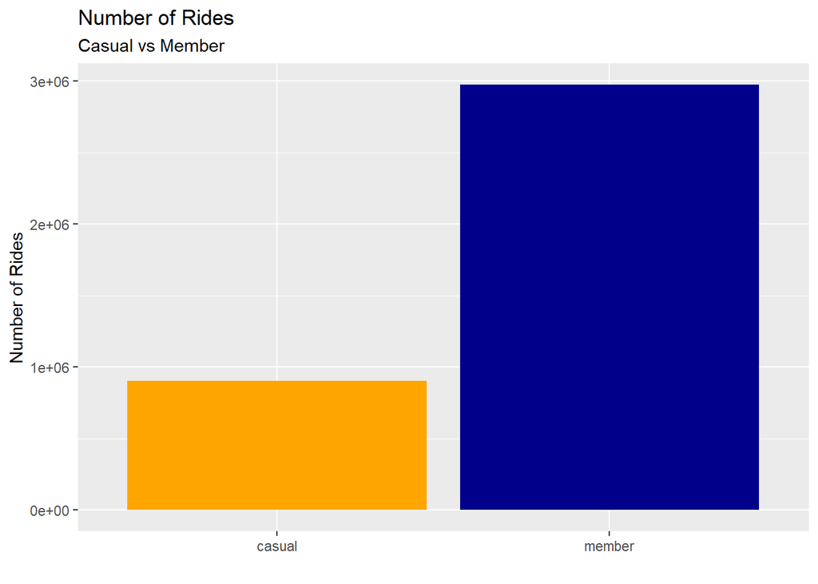

```r
res1 %>%
  ggplot(aes(x = member_casual, y = number_of_rides)) +
  geom_col(aes(fill = number_of_rides)) +
  scale_fill_gradient2(low = "orange",
                       high = "darkblue",
                       midpoint = median(res1$number_of_rides)) +
  theme(legend.position = "none") +
  xlab("") +
  ylab("Number of Rides") +
  labs(title = "Number of Rides", subtitle = "Casual vs Member")
```

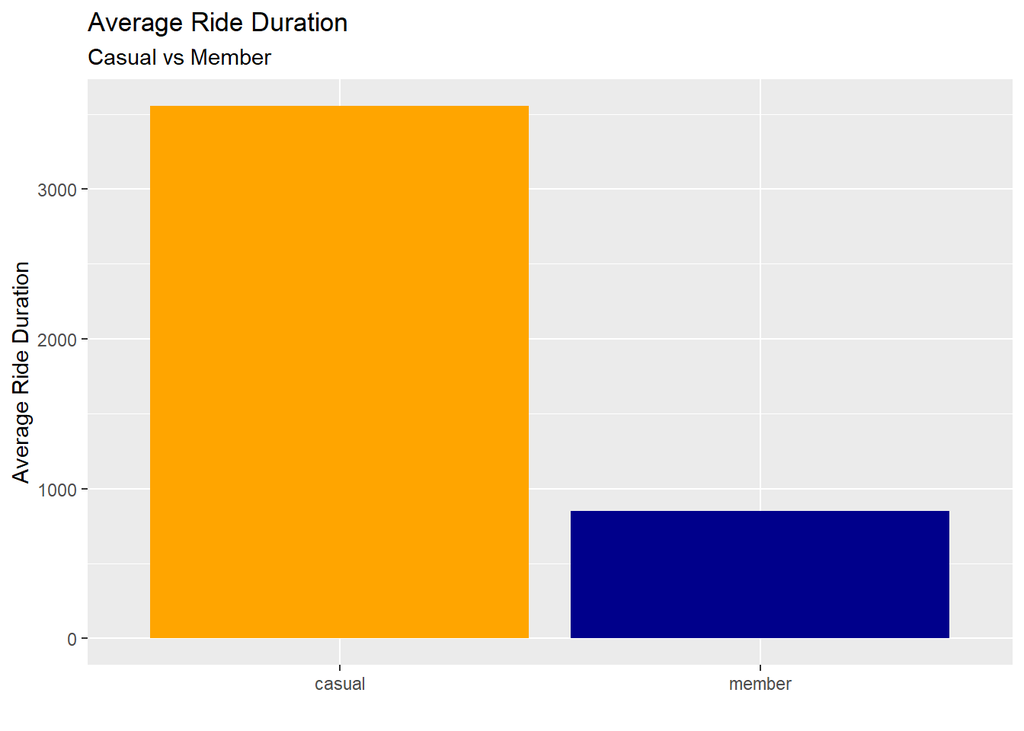

```r
res1 %>%
  ggplot(aes(x = member_casual, y = mean_ride_duration)) +
  geom_col(aes(fill = mean_ride_duration)) +
  scale_fill_gradient2(low = "darkblue",
                       high = "orange",
                       midpoint = median(res1$mean_ride_duration)) +
  theme(legend.position = "none") +
  xlab("") +
  ylab("Average Ride Duration") +
  labs(title = "Average Ride Duration", subtitle = "Casual vs Member")
```

- It seems like casual riders uses the bikes less frequently but for a longer period of time! There must be a reason for this.
- Let’s take a look at how casual riders and members’ ridership data by each weekday!

#### Average ride duration by each day for casual users and members:

```r
setNames(aggregate(divvy_trips_cleaned$ride_duration
                  ~ divvy_trips_cleaned$member_casual
                  + divvy_trips_cleaned$day_of_week
                  , FUN = mean)
          , c("member/casual", "day_of_week", "ride_duration_mean"))
```

```
##    member/casual day_of_week ride_duration_mean
## 1         casual      Sunday          3581.4054
## 2         member      Sunday           919.9746
## 3         casual      Monday          3372.2869
## 4         member      Monday           842.5726
## 5         casual     Tuesday          3596.3599
## 6         member     Tuesday           826.1427
## 7         casual   Wednesday          3718.6619
## 8         member   Wednesday           823.9996
## 9         casual    Thursday          3682.9847
## 10        member    Thursday           823.9278
## 11        casual      Friday          3773.8351
## 12        member      Friday           824.5305
## 13        casual    Saturday          3331.9138
## 14        member    Saturday           968.9337
```

- At first glance, average ride duration on each day seems to be significantly higher for casual riders than members, which aligns with what was previously analyzed.
- Let’s visualize this in a chart!

## Analyze ridership data by type and weekday

```r
res2 <- divvy_trips_cleaned %>%
  group_by(member_casual, day_of_week) %>%
  summarize(number_of_rides = n()
            , mean_ride_duration = mean(ride_duration)) %>%
  arrange(member_casual, day_of_week)
```

#### Average Ride Duration Throughout the Week (casual vs member)

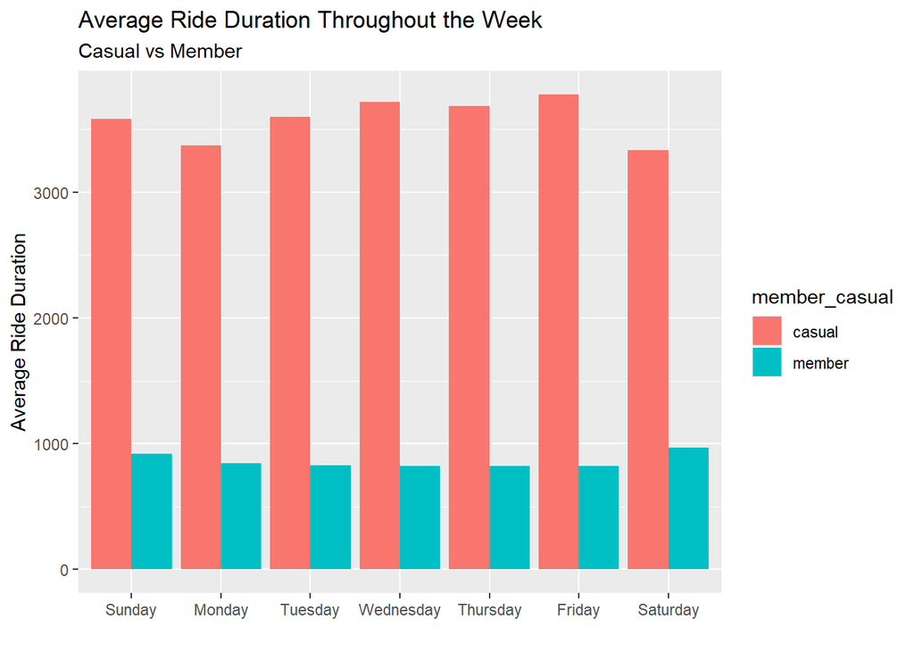

```r
res2 %>%
  ggplot(aes(x = day_of_week, y = mean_ride_duration, fill = member_casual)) +
  geom_col(position = "dodge") +
  xlab("") +
  ylab("Average Ride Duration") +
  labs(title = "Average Ride Duration Throughout the Week"
       , subtitle = "Casual vs Member")
```

- The average ride duration throughout the week seems to be consistent for both types of riders even though members ride the bikes more often!

#### Number of Rides Throughout the Week

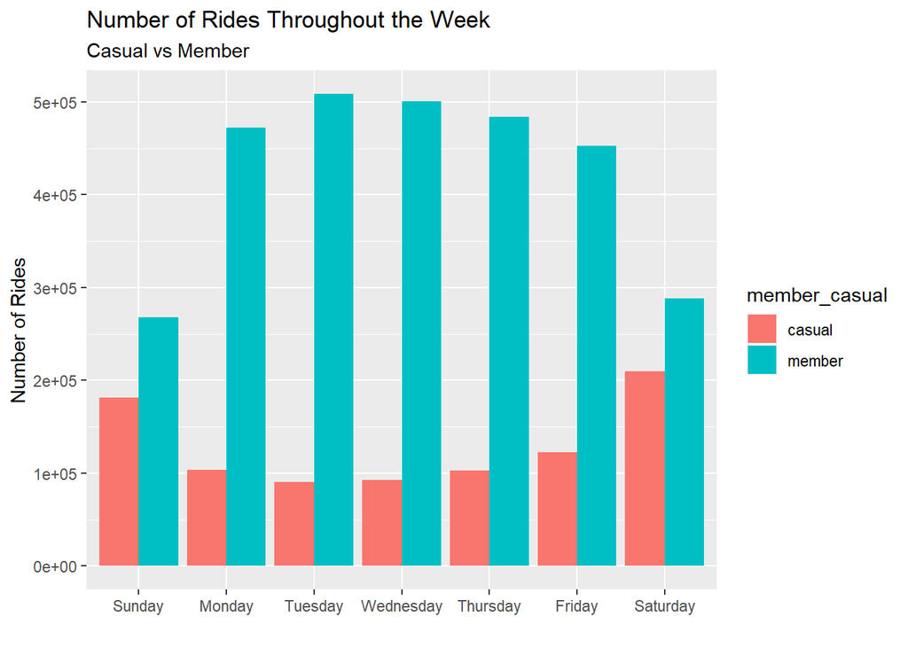

```r
res2 %>%
  ggplot(aes(x = day_of_week, y = number_of_rides, fill = member_casual)) +
  geom_col(position = "dodge") +
  xlab("") +
  ylab("Number of Rides") +
  labs(title = "Number of Rides Throughout the Week"
       , subtitle = "Casual vs Member")
```

- There seems to be a pattern here!
- The y-axis scale for member and casual riders are very different, making it difficult to see the trend.
- Let’s visualize members and casual riders separately!

#### Visualize trend of number of rides of casual riders throughout the week

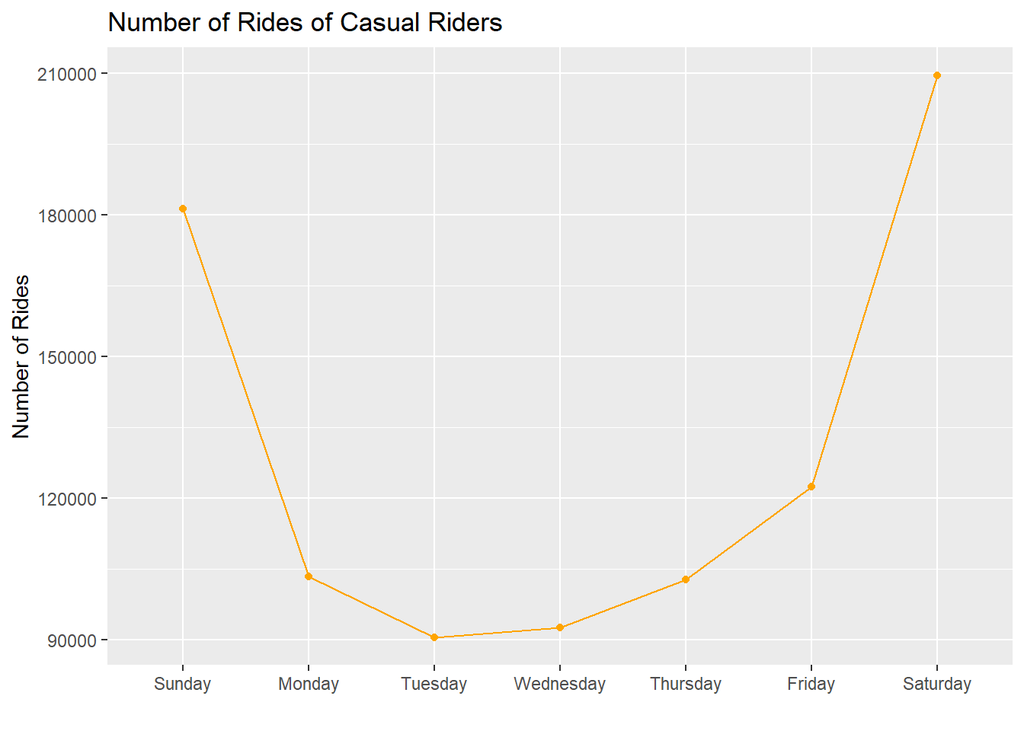

```r
res2 %>%
  filter(member_casual == "casual") %>%
  ggplot(aes(x = day_of_week, y = number_of_rides, group = 1)) +
  geom_point(color = "orange") +
  geom_line(color = "orange") +
  xlab("") +
  ylab("Number of Rides") +
  labs(title = "Number of Rides of Casual Riders")
```

#### Visualize trend of number of rides of members throughout the week

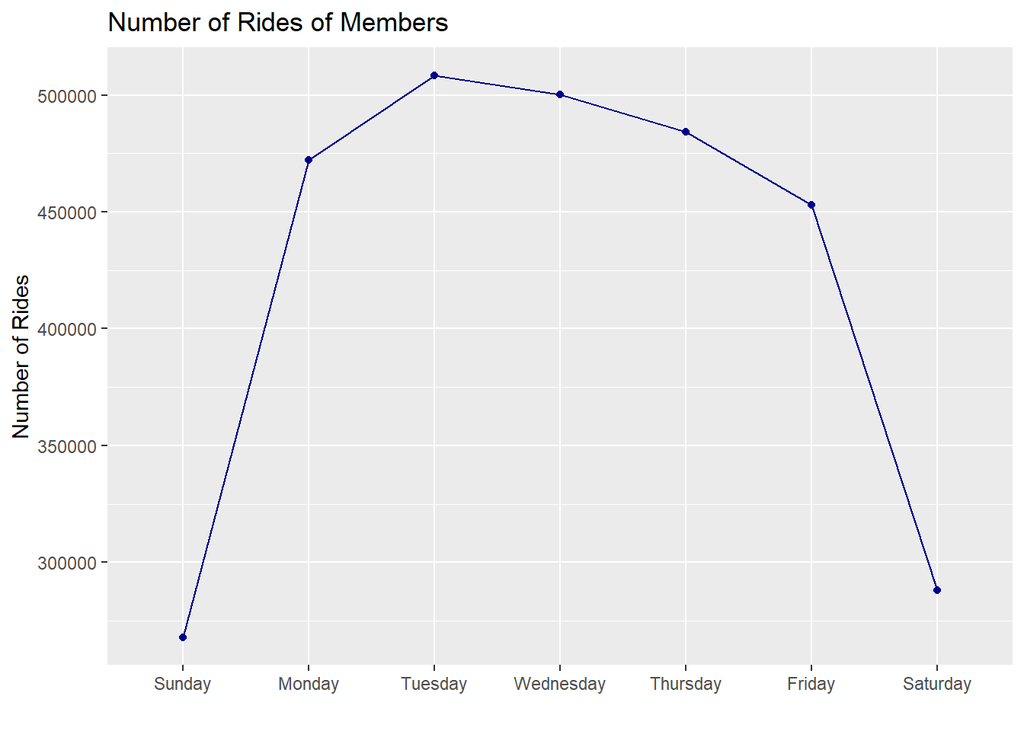

```r
res2 %>%
  filter(member_casual == "member") %>%
  ggplot(aes(x = day_of_week, y = number_of_rides, group = 1)) +
  geom_point(color = "darkblue") +
  geom_line(color = "darkblue") +
  xlab("") +
  ylab("Number of Rides") +
  labs(title = "Number of Rides of Members")
```

## Analyse ridership data by Type and Month

```r
res3 <- divvy_trips_cleaned %>%
  group_by(member_casual, month) %>%
  summarize(number_of_rides = n()
            , mean_ride_duration = mean(ride_duration)) %>%
  arrange(member_casual, month)
```

#### Average Ride Duration of casual riders and members by Months

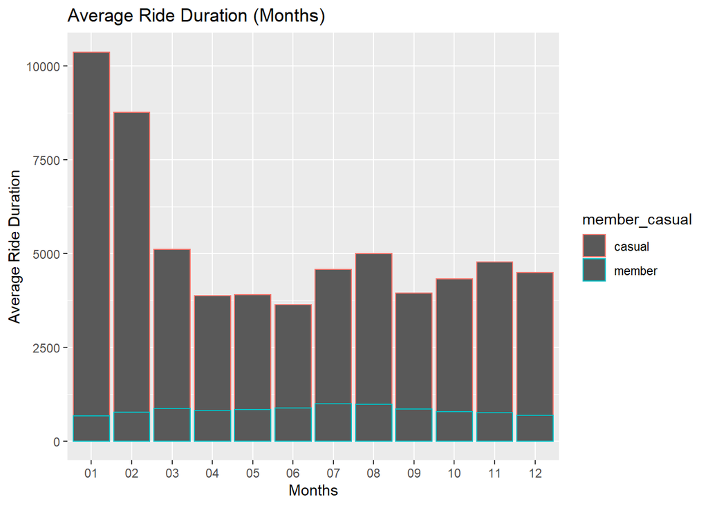

```r
res3 %>%
  ggplot(aes(x = month, y = mean_ride_duration, color = member_casual)) +
  geom_col() +
  xlab("Months") +
  ylab("Average Ride Duration") +
  labs(title = "Average Ride Duration (Months)")
```

- There seems to be a pattern for casual riders in their average ride duration from month to month! Let’s visualize them separately!

#### Average Ride Duration of casual riders by Months

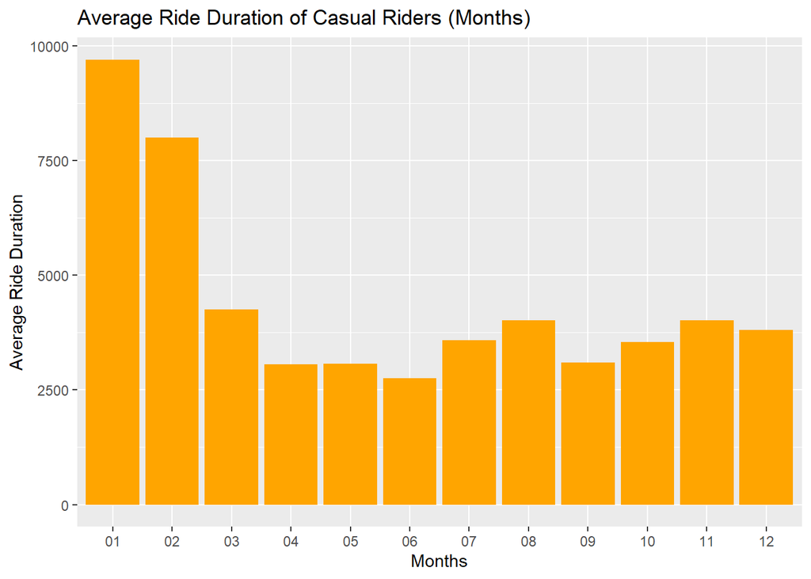

```r
res3 %>%
  filter(member_casual == "casual") %>%
  ggplot(aes(x = month, y = mean_ride_duration)) +
  geom_col(fill = "orange") +
  xlab("Months") +
  ylab("Average Ride Duration") +
  labs(title = "Average Ride Duration of Casual Riders (Months)")
```

- The bar graph looks right skewed! It seems like casual riders use the bikes significantly longer in the first few months of a year!
- This may be due to casual riders using the bikes longer as a form of exercise in order to meet their New Year’s resolution!

#### Average Ride Duration of members by Months

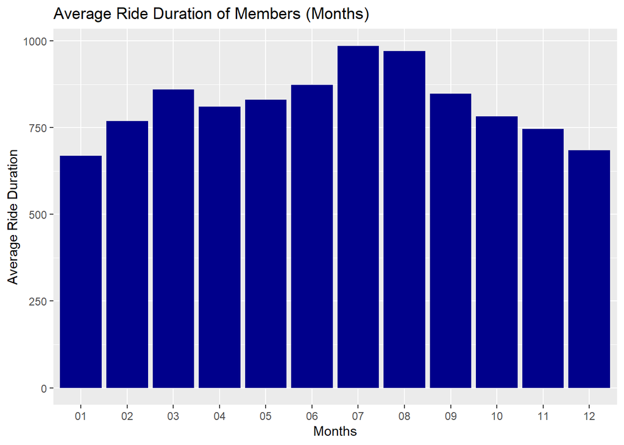

```r
res3 %>%
  filter(member_casual == "member") %>%
  ggplot(aes(x = month, y = mean_ride_duration)) +
  geom_col(fill = "darkblue") +
  xlab("Months") +
  ylab("Average Ride Duration") +
  labs(title = "Average Ride Duration of Members (Months)")
```

# Export data sets for further analysis and visualisation:

```r
write.csv(divvy_trips_cleaned, 'Dataset/divvy_trips_cleaned.csv')
write.csv(res1, 'Dataset/res1.csv')
write.csv(res2, 'Dataset/res2.csv')
write.csv(res3, 'Dataset/res3.csv')
```

# Conclusion of Analysis:

### Casual Riders:

##### Overall: Casual riders uses the bikes less frequently but for a longer period of time

# Recommendations:

1. Advertise during New Year’s period to convince casual riders to convert to members
2. Encourage casual riders to sign up for membership to use bikes as alternative mode of transportation, for health and environment
3. Introduce an exclusive members’ community with members’ only bonding and relaxation events/activities

# Future Improvements:

- Collect survey data for analysis to better understand the decision-making mindset of casual riders vs members.
- A larger data set can be used for analyzing longer term trends and behaviors of riders.
- The start and end stations can be analyzed to see if there are any particular areas that have more members and find the reasons for such occurrences.